# Lecture 2: EDA; aesthetic mappings

```r
suppressPackageStartupMessages(library(tidyverse))
library(gapminder)
knitr::opts_chunk$set(fig.width=5, fig.height=3, fig.align="center")
```

# Learning Objectives

Here is what we expect you to know, corresponding to today’s lecture:

- Draw conclusions from a graph regarding the effect and confidence
- Identify the grammar components from a graph
- Identify the graph from grammar components
- Identify an appropriate graph given the variable types to be depicted
  - There’s more room for flexibility when there are 3+ data variables

You are not expected to memorize the names of the plot types for your quizzes.

# Review

Last time, we mostly looked at:

1. Components: what *is* a statistical graphic (or “graph”)?
   - Defined by the grammar of graphics
2. Tooling: how to make a plot (with `ggplot2`)
   - Use case: appropriate plots given the types of variables to be plotted.

Elaborate:

- What are the grammar components?
  - Correction from last time: aesthetic vs aesthetic *mapping*.
- What are the appropriate plots for…
  - (First of all, what are the two main types of variables? )
  - 2 numeric variables?
  - 1 numeric variable?
  - 1 numeric, 1 categorical variable?

We’ve also been getting set up for the other three main elements of this course

(we can think of these as a forming a flowchart: effective choice -> components + theme -> tooling -> EDA)

3. Theming: the look/decorations on a plot.
   - Lecture 3 (in part)
4. Exploratory Data Analysis (EDA)
   - Elaboration today (soon).
5. Plotting Effectiveness
   - Chiefly Lecture 5
   - Plotting principal alluded to so far: show me the data!
   - Example: pinhead plots vs. violin+jitter plots.

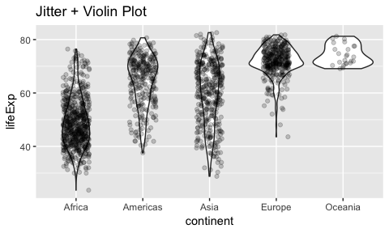

```r
ggplot(gapminder, aes(continent, lifeExp)) +
    geom_violin() +
    geom_jitter(width=0.2, alpha=0.2) +
    ggtitle("Jitter + Violin Plot")
```

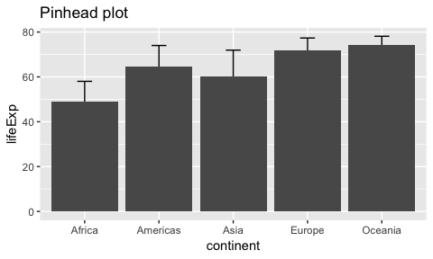

```r
gapminder %>%
    group_by(continent) %>%
    summarize(sd = sd(lifeExp),
              mean_life_exp = mean(lifeExp)) %>%
    ggplot(aes(continent)) +
    geom_errorbar(aes(ymax = mean_life_exp + sd,
                      ymin = mean_life_exp - sd),
                  width=0.2) +
    geom_col(aes(y=mean_life_exp)) +
    ggtitle("Pinhead plot") +
    ylab("lifeExp")
```

# Today

- EDA
- Continue 1- and 2-variable plot types.
- 3+ variable plot types (through more aesthetics, and facetting).

We’ll fill out the `lec2-worksheet.Rmd` worksheet for the latter two.

# EDA

## Intro

What is exploratory data analysis (EDA)? (What is Data Science?) There’s no one definition. Generally:

- Answering questions through data exploration; as opposed to making model assumptions, model fitting, or hypothesis tests.
- Allows for us to answer questions qualitatively (not numerically). Questions are typically less specific and more “human”:
  - “Has life expectancy been increasing over time?”
  - vs. specifying mean
- Usually the first part of an analysis.

When reading a plot, there are generally two main components to consider:

- Effect (example: is there a relationship/trend?)
- Confidence (in the effect)

(Link to 552: estimate + uncertainty)

## Examples of EDA

Which species has the largest Sepal Width? How certain are you? (Did I need a hypothesis test for this? This is not to say that hypothesis tests are not useful)

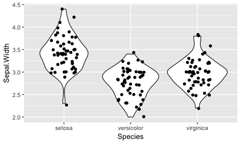

```r
iris %>%
    ggplot(aes(Species, Sepal.Width)) +
    geom_violin() +
    geom_jitter(width=0.2)
```

Which continent will have the highest life expectancy in 2020? Will a model help you here?

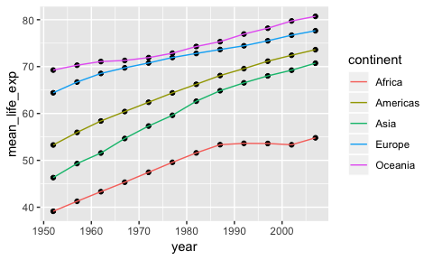

```r
gapminder %>%
    group_by(continent, year) %>%
    summarize(mean_life_exp = mean(lifeExp)) %>%
    ggplot(aes(year, mean_life_exp)) +
    geom_point() +
    geom_line(aes(colour=continent, group=continent))
```

Is there a relationship between GDP per capita and life expectancy? Describe the dependence. How confident are you?

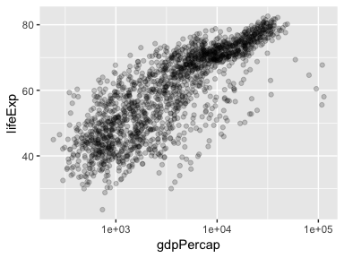

```r
ggplot(gapminder, aes(gdpPercap, lifeExp)) +
    geom_point(alpha=0.2) +
    scale_x_log10()
```

How certain are you with this one?

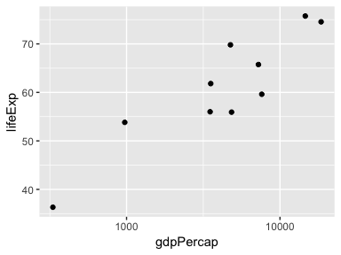

```r
set.seed(10)
gapminder %>%
    sample_n(10) %>%
    ggplot(aes(gdpPercap, lifeExp)) +
    geom_point() +
    scale_x_log10()
```

Is there a relationship between the sepal and petal lengths of the setosa plant? How confident are you?

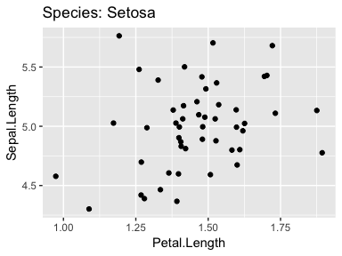

```r
iris %>%
    filter(Species == "setosa") %>%
    ggplot(aes(Petal.Length, Sepal.Length)) +
    geom_jitter() +
    ggtitle("Species: Setosa")
```

Poll:

`/poll Dependence strong weak none`

`/poll "Confidence" "highly confident", "somewhat confident", "little confidence", "no confidence"`